# Forest Modelling Workflow

Marvin Ludwig

30/10/2020

# Data Basis

## Predictors

- Sentinel-2 for winter and summer 2019 ** Vegetation indices from R package RStoolbox
- Lidar Data from RLP (data at hand) ** From multiple years (2013 - 2019) ** some parts at the border to Luxemburg are missing ** Lidar indices from RSDB (no intensity based indices)

## Observations

- Forest inventory for all state-owned forest (~ 60% of all forest in RLP) ** Tree species ** Waldwachstumsphase

## Supplementary

- Hansen - Global forest cover
- Bundeswaldinventur

# Stage 1: Getting the forest

- Reduced predictors to areas where there is forest in the Hansen-Set
- Reduced observation polygons to those with 80% species purity
- Combined subclasses (e.g. *Quercus petraea* and *Quercus robur*)

# Stage 2: Modelling approach

### Hirachical modelling:

1. Modell the tree species ** One model with main species (*Fagus*, *Quercus*, *Pseudotsuga*, *Picea*, *Pinus*) ** One model with main species + lesser species (*Larix*, *Deciduous short living*, *Deciduous long living*)
2. Modell the quality classes within the species ** 2 or 3 quality classes for each tree species ** These model are only valid where the tree species models predict the actual tree species ** Reasoning: Forest quality stages are much harder to identify + there are less training areas for each quality class. This way we get robust models for tree species and still predict forest quality

Since the tree species are not equally distributed (e.g. much more Polygons with *Fagus* than *Picea*) the class with the lowest and smallest polygons determines the sampling size. In each model, the same amount of pixel per class gets sampled.

# Stage 3: Modelling

- Random Forest with FFS
- 10-Fold Leave Locations Out Cross Validation
- Area of Applicability for each model
- Independent validation with the polygons which did not get sampled previously (much more than the training set)

# Model Examples

## Tree species

```
## $Model
## [1] "meta_classes_diverse"
##
## $`Number of training polygons`
## [1] 408
##
## $`Number of training pixel per class`
## $`Number of training pixel per class`$Bu
## [1] 1632
##
## $`Number of training pixel per class`$Dou
## [1] 1632
##
## $`Number of training pixel per class`$Ei
## [1] 1632
##
## $`Number of training pixel per class`$Fi
## [1] 1632
##
## $`Number of training pixel per class`$Ki
## [1] 1632
##
## $`Number of training pixel per class`$Lä
## [1] 1632
##
## $`Number of training pixel per class`$Lbk
## [1] 1632
##
## $`Number of training pixel per class`$Lbl
## [1] 1632
##
##
## $`Number of validation polygons`
## [1] 9465
##
## $`Number of validation pixel per class`
## $`Number of validation pixel per class`$Bu
## [1] 211090
##
## $`Number of validation pixel per class`$Dou
## [1] 44785
##
## $`Number of validation pixel per class`$Ei
## [1] 172435
##
## $`Number of validation pixel per class`$Fi
## [1] 147061
##
## $`Number of validation pixel per class`$Ki
## [1] 201680
##
## $`Number of validation pixel per class`$Lä
## [1] 945
##
## $`Number of validation pixel per class`$Lbk
## [1] 4004
##
## $`Number of validation pixel per class`$Lbl
## [1] 6030
```

```
## $positive
## NULL
##
## $table
##         Predicted
## Observed     Bu    Dou     Ei     Fi     Ki     Lä    Lbk    Lbl
##      Bu  166289    959  13449   1511   8119   3676   4968  12119
##      Dou    155  39976    133   2086   1717    199    329    190
##      Ei   22361    658  97605    378   2033   6875  14352  28173
##      Fi    1688   6717    466 124368   9649   2063   1548    562
##      Ki    7285   2024   1901   5366 176859   2997   3518   1730
##      Lä      25      9     68      7      6    784      6     40
##      Lbk    122     49    466     65    157    484   2291    370
##      Lbl    359     61   1617     11    169     88   1193   2532
##
## $overall
##       Accuracy          Kappa  AccuracyLower  AccuracyUpper   AccuracyNull
##      0.7749756      0.7187055      0.7740519      0.7758972      0.2521592
## AccuracyPValue  McnemarPValue
##      0.0000000      0.0000000
##
## $byClass
##            Sensitivity Specificity Pos Pred Value Neg Pred Value Precision
## Class: Bu   0.83864054   0.9240334      0.7877635      0.9445436 0.7877635
## Class: Dou  0.79234139   0.9934800      0.8926203      0.9859037 0.8926203
## Class: Ei   0.84356769   0.8886997      0.5660394      0.9705976 0.5660394
## Class: Fi   0.92956231   0.9653138      0.8456899      0.9852973 0.8456899
## Class: Ki   0.89004021   0.9578820      0.8769288      0.9627356 0.8769288
## Class: Lä   0.04567168   0.9997911      0.8296296      0.9791865 0.8296296
## Class: Lbk  0.08122673   0.9977455      0.5721778      0.9669475 0.5721778
## Class: Lbl  0.05538542   0.9952877      0.4199005      0.9447775 0.4199005
##                Recall         F1 Prevalence Detection Rate Detection Prevalence
## Class: Bu  0.83864054 0.81240626 0.25161986    0.211018616          0.267870513
## Class: Dou 0.79234139 0.83949684 0.06402421    0.050729033          0.056831593
## Class: Ei  0.84356769 0.67748317 0.14682817    0.123859498          0.218817812
## Class: Fi  0.92956231 0.88564480 0.16978034    0.157821403          0.186618530
## Class: Ki  0.89004021 0.88343586 0.25215918    0.224431811          0.255929343
## Class: Lä  0.04567168 0.08657722 0.02178343    0.000994886          0.001199193
## Class: Lbk 0.08122673 0.14225837 0.03579178    0.002907250          0.005081025
## Class: Lbl 0.05538542 0.09786264 0.05801302    0.003213076          0.007651993
##            Balanced Accuracy
## Class: Bu          0.8813370
## Class: Dou         0.8929107
## Class: Ei          0.8661337
## Class: Fi          0.9474381
## Class: Ki          0.9239611
## Class: Lä          0.5227314
## Class: Lbk         0.5394861
## Class: Lbl         0.5253366
##
## $mode
## [1] "sens_spec"
##
## $dots
## list()
##
## attr(,"class")
## [1] "confusionMatrix"
```

## Forest quality

```
## $Model
## [1] "quality_beech"
##
## $`Number of training polygons`
## [1] 249
##
## $`Number of training pixel per class`
## $`Number of training pixel per class`$Bu_Dim
## [1] 5810
##
## $`Number of training pixel per class`$Bu_Qua
## [1] 5810
##
## $`Number of training pixel per class`$Bu_Rei
## [1] 5810
##
##
## $`Number of validation polygons`
## [1] 1950
##
## $`Number of validation pixel per class`
## $`Number of validation pixel per class`$Bu_Dim
## [1] 40630
##
## $`Number of validation pixel per class`$Bu_Qua
## [1] 3765
##
## $`Number of validation pixel per class`$Bu_Rei
## [1] 136071
```

```
## $positive
## NULL
##
## $table
##         Predicted
## Observed Bu_Dim Bu_Qua Bu_Rei
##   Bu_Dim  24552   7011   9067
##   Bu_Qua    667   2809    289
##   Bu_Rei  33311  12932  89828
##
## $overall
##       Accuracy          Kappa  AccuracyLower  AccuracyUpper   AccuracyNull
##      0.6493689      0.3124262      0.6471622      0.6515707      0.5495994
## AccuracyPValue  McnemarPValue
##      0.0000000      0.0000000
##
## $byClass
##               Sensitivity Specificity Pos Pred Value Neg Pred Value Precision
## Class: Bu_Dim   0.4194772   0.8681439      0.6042825      0.7570154 0.6042825
## Class: Bu_Qua   0.1234617   0.9939384      0.7460823      0.8871370 0.7460823
## Class: Bu_Rei   0.9056703   0.4310795      0.6601554      0.7892555 0.6601554
##                  Recall        F1 Prevalence Detection Rate
## Class: Bu_Dim 0.4194772 0.4951997  0.3243270     0.13604779
## Class: Bu_Qua 0.1234617 0.2118641  0.1260736     0.01556526
## Class: Bu_Rei 0.9056703 0.7636650  0.5495994     0.49775581
##               Detection Prevalence Balanced Accuracy
## Class: Bu_Dim           0.22513936         0.6438106
## Class: Bu_Qua           0.02086266         0.5587000
## Class: Bu_Rei           0.75399798         0.6683749
##
## $mode
## [1] "sens_spec"
##
## $dots
## list()
##
## attr(,"class")
## [1] "confusionMatrix"
```

## Tree species prediction

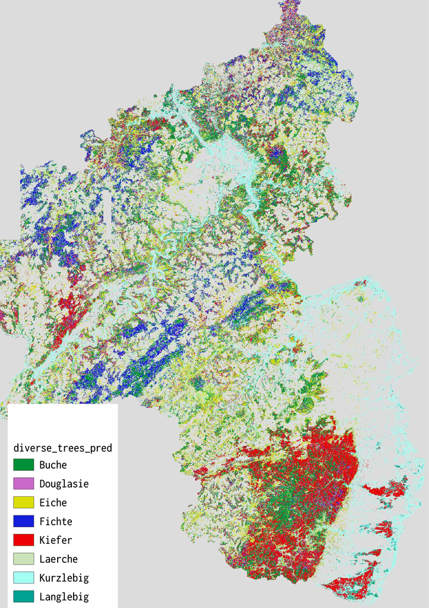

Tree species map

## AOA Example

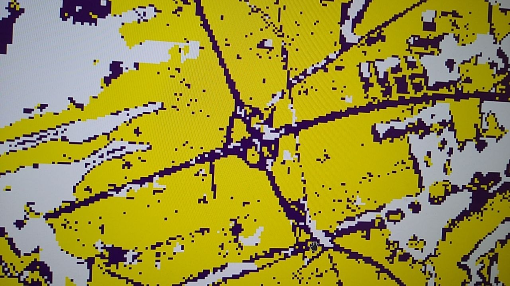

AOA Example